# The effects of severe weather events across the United States

Rocco Barbini

20 agosto 2015

## Synopsis

This analysis investigates the effects of the severe weather events that were recorded by NOAA across the United States between 1950 and 2011.

The data was analysed without considering the year or the State where the events took place. Moreover, since the data was nos tidy, a cleanup of the dataset was performed before the analysis. These factors should be taken into account and caution should be used when using the results as the basis for policy decisions.

The results are presented at the end of this document, separating the economic effects from those on the population health. The data processing section, which is the longer part of this report, will be of interest to the data analysts who may want to reproduce this analysis and to check if it was performed correctly.

The data set was downloaded from https://d396qusza40orc.cloudfront.net/repdata%2Fdata%2FStormData.csv.bz2 on August 20th, 2015.

## Data Processing

To process the data, I used the following libraries:

```r
suppressWarnings(require(dplyr))
```

```r
suppressWarnings(require(ggplot2))
```

The dataset is very large and includes a variety of columns that are not relevant to my analysis. In order to make the calculations lighter on my computer, I therefore:

- loaded the data set;
- created a subset with the relevant columns;
- removed the original data set and performed an iterative garbage collection process.

```r
# do_collect_garbage()
#
# This function collects garbage efficiently to free up memory
#
do_collect_garbage <- function(x) {
        Sys.sleep(1)
        invisible(gc())
        Sys.sleep(1)
        invisible(gc())
        Sys.sleep(1)
        invisible(gc())
        Sys.sleep(1)
        invisible(gc())
}

storm_data <- read.csv("Data/storm_data.csv.bz2", header = T, stringsAsFactors = T)
subset <- select(storm_data, EVTYPE, FATALITIES, INJURIES, PROPDMG, PROPDMGEXP, CROPDMG, CROPDMGEXP)
rm(storm_data)
do_collect_garbage()
```

Since there are too many event types, I began to clean them up by removing those that produced no damage and are therefore irrelevant to my analysis. I then cleaned up my temporary variables and freed up some more memory.

```r
tmp_levels <- length(levels(subset$EVTYPE))
evtypes_dmg <- aggregate(x = (subset[, "PROPDMG"] + subset[, "CROPDMG"] + subset[, "INJURIES"] + subset[, "FATALITIES"]), by = list(subset[, "EVTYPE"]), FUN = "sum")
irrelevant_evtypes <- filter(evtypes_dmg, x == 0) %>% select(Group.1)
subset <- filter(subset, !(EVTYPE %in% unlist(irrelevant_evtypes)))
subset <- droplevels(subset)
erased_levels <- tmp_levels - length(levels(subset$EVTYPE))
rm(evtypes_dmg)
rm(irrelevant_evtypes)
rm(tmp_levels)
do_collect_garbage()
```

This way I was able to remove 497 levels with no cumulated damage to either health or property.

### Cleaning up the Event Types

I then proceeded to tidy up the EVTYPE values. This required some judgement calls, as I had to adapt the “recorded” event types to the categories quoted in NOAA documents. Those categories are the following:

```r
correct_event_types <- c("Astronomical Low Tide", "Avalanche", "Blizzard", "Coastal Flood", "Cold/Wind Chill", "Debris Flow", "Dense Fog", "Dense Smoke", "Drought", "Dust Devil", "Dust Storm", "Excessive Heat", "Extreme Cold/Wind Chill", "Flash Flood", "Flood", "Freezing Fog", "Frost/Freeze", "Funnel Cloud", "Hail", "Heat", "Heavy Rain", "Heavy Snow", "High Surf", "High Wind", "Hurricane/Typhoon", "Ice Storm", "Lakeshore Flood", "Lake-Effect Snow", "Lightning", "Marine Hail", "Marine High Wind", "Marine Strong Wind", "Marine Thunderstorm Wind", "Rip Current", "Seiche", "Sleet", "Storm Tide", "Strong Wind", "Thunderstorm Wind", "Tornado", "Tropical Depression", "Tropical Storm", "Tsunami", "Volcanic Ash", "Waterspout", "Wildfire", "Winter Storm", "Winter Weather")
correct_event_types_count <- length(correct_event_types)
recorded_event_types_count <- length(levels(subset$EVTYPE))
```

Note that there are 48 admitted categories, but 488 variations were actually recorded.

I determined the sequence of the instructions to tidy the data based on my judgement, giving priority to what looked like the most specific, then to the most important/severe events in those cases in which mixed events were reported.

Ultimately, not being an expert on this subject, I could reduce the event types only partially. In some cases, I had to invent my own categories (e.g. MUDSLIDES) in order to at least reduce the number of duplicates.

In some cases I also had to introduce a false value (e.g. COASTAL FLOOKD) so that I could use a more generic rule (e.g. to set the event type“FLOOD”), then I corrected the false value.

My first series of corrections dealt with:

- the ? value;
- waterspouts;
- tornadoes;
- thunderstorms;
- hail;
- avalanches;
- blizzards;
- dust storms;
- ice storms;
- winter storms;
- tropical storms;
- flash floods;
- coastal floods;
- lakeshore floods;
- mudslides;
- floods.

```r
old_event_types_count <- length(levels(subset$EVTYPE))
subset$EVTYPE <- plyr::revalue(subset$EVTYPE, c("?"="UNKNOWN"))
levels(subset$EVTYPE)<- gsub(".*waterspout.*", "WATERSPOUT", levels(subset$EVTYPE), ignore.case = T)
levels(subset$EVTYPE)<- gsub(".*tornado.*", "TORNADO", levels(subset$EVTYPE), ignore.case = T)
levels(subset$EVTYPE)<- gsub(".*gustnado.*", "TORNADO", levels(subset$EVTYPE), ignore.case = T, perl = T)
levels(subset$EVTYPE)<- gsub(".*torndao.*", "TORNADO", levels(subset$EVTYPE), ignore.case = T, perl = T)
levels(subset$EVTYPE)<- gsub("^thunderstorm hail$", "HAIL", levels(subset$EVTYPE), ignore.case = T)
levels(subset$EVTYPE)<- gsub("^thunderstorm.*", "THUNDERSTORM WIND", levels(subset$EVTYPE), ignore.case = T)
levels(subset$EVTYPE)<- gsub(".*microburst.*", "THUNDERSTORM WIND", levels(subset$EVTYPE), ignore.case = T)
levels(subset$EVTYPE)<- gsub(".*mircoburst.*", "THUNDERSTORM WIND", levels(subset$EVTYPE), ignore.case = T)
levels(subset$EVTYPE)<- gsub("^lightning.*thunderstorm.*", "THUNDERSTORM WIND", levels(subset$EVTYPE), ignore.case = T)
levels(subset$EVTYPE)<- gsub("^severe.*thunderstorm.*", "THUNDERSTORM WIND", levels(subset$EVTYPE), ignore.case = T)
levels(subset$EVTYPE)<- gsub("^tstm.*", "THUNDERSTORM WIND", levels(subset$EVTYPE), ignore.case = T)
levels(subset$EVTYPE)<- gsub("^tuderstorm.*", "THUNDERSTORM WIND", levels(subset$EVTYPE), ignore.case = T)
levels(subset$EVTYPE)<- gsub("^tunderstorm.*", "THUNDERSTORM WIND", levels(subset$EVTYPE), ignore.case = T)
levels(subset$EVTYPE)<- gsub("^thuderstorm.*", "THUNDERSTORM WIND", levels(subset$EVTYPE), ignore.case = T)
levels(subset$EVTYPE)<- gsub("^ tstm.*", "THUNDERSTORM WIND", levels(subset$EVTYPE), ignore.case = T)
levels(subset$EVTYPE)<- gsub(".*hail.*", "HAIL", levels(subset$EVTYPE), ignore.case = T)
levels(subset$EVTYPE)<- gsub("MARINE TSTM WIND", "MARINE THUNDERSTORM WIND", levels(subset$EVTYPE), ignore.case = T)
levels(subset$EVTYPE)<- gsub("^thun.*", "THUNDERSTORM WIND", levels(subset$EVTYPE), ignore.case = T)
levels(subset$EVTYPE)<- gsub(".*avalanche.*", "AVALANCHE", levels(subset$EVTYPE), ignore.case = T)
levels(subset$EVTYPE)<- gsub(".*blizzard.*", "BLIZZARD", levels(subset$EVTYPE), ignore.case = T)
levels(subset$EVTYPE)<- gsub(".*dust storm.*", "DUST STORM", levels(subset$EVTYPE), ignore.case = T)
levels(subset$EVTYPE)<- gsub(".*ice storm$", "ICE STORM", levels(subset$EVTYPE), ignore.case = T)
levels(subset$EVTYPE)<- gsub(".*winter storm.*", "WINTER STORM", levels(subset$EVTYPE), ignore.case = T)
levels(subset$EVTYPE)<- gsub(".*tropical storm.*", "TROPICAL STORM", levels(subset$EVTYPE), ignore.case = T)
levels(subset$EVTYPE)<- gsub(".*flash.*flood.*", "FLASH FLOOkD", levels(subset$EVTYPE), ignore.case = T)
levels(subset$EVTYPE)<- gsub(".*flood.*flash.*", "FLASH FLOOkD", levels(subset$EVTYPE), ignore.case = T)
levels(subset$EVTYPE)<- gsub(".*coast.*flood.*", "COASTAL FLOOkD", levels(subset$EVTYPE), ignore.case = T)
levels(subset$EVTYPE)<- gsub(".*cstl.*flood.*", "COASTAL FLOOKD", levels(subset$EVTYPE), ignore.case = T)
levels(subset$EVTYPE)<- gsub(".*lake.*flood.*", "LAKESHORE FLOOkD", levels(subset$EVTYPE), ignore.case = T)
levels(subset$EVTYPE)<- gsub(".*mud.*", "MUDSLIDES", levels(subset$EVTYPE), ignore.case = T)
levels(subset$EVTYPE)<- gsub(".*flood.*", "FLOOD", levels(subset$EVTYPE), ignore.case = T)
levels(subset$EVTYPE)<- gsub("FLASH FLOOKD", "FLASH FLOOD", levels(subset$EVTYPE), ignore.case = T)
levels(subset$EVTYPE)<- gsub("COASTAL FLOOKD", "COASTAL FLOOD", levels(subset$EVTYPE), ignore.case = T)
levels(subset$EVTYPE)<- gsub("LAKESHORE FLOOKD", "LAKESHORE FLOOD", levels(subset$EVTYPE), ignore.case = T)
subset <- droplevels(subset)
new_event_types_count <- length(levels(subset$EVTYPE))
diff_event_types_count <- old_event_types_count - new_event_types_count
rm(old_event_types_count)
do_collect_garbage()
```

This operation allowed me to clean up 193 values. But I still have 247 more values than the expected 48.

Following the first round, I performed a second round of cleanups:

```r
old_event_types_count <- length(levels(subset$EVTYPE))
levels(subset$EVTYPE)<- gsub(".*devil.*", "DUST DEVIL", levels(subset$EVTYPE), ignore.case = T)
levels(subset$EVTYPE)<- gsub("BLOWING DUST", "DUST STORM", levels(subset$EVTYPE), ignore.case = T)
levels(subset$EVTYPE)<- gsub(".*drought.*", "DROUGHT", levels(subset$EVTYPE), ignore.case = T)
levels(subset$EVTYPE)<- gsub(".+heat", "EXCESSIVE HEAT", levels(subset$EVTYPE), ignore.case = T)
levels(subset$EVTYPE)<- gsub("^heat.*", "HEAT", levels(subset$EVTYPE), ignore.case = T)
levels(subset$EVTYPE)<- gsub("^(?!.*ext).*chill.*", "COLD/WINKD CHILL", levels(subset$EVTYPE), ignore.case = T, perl = T)
levels(subset$EVTYPE)<- gsub(".*ext.*chill.*", "EXTREME COLD/WINKD CHILL", levels(subset$EVTYPE), ignore.case = T)
levels(subset$EVTYPE)<- gsub(".*lake.*snow.*", "LAKE-EFFECT SNOW", levels(subset$EVTYPE), ignore.case = T)
levels(subset$EVTYPE)<- gsub(".*hea.*snow.*", "HEAVY SNOW", levels(subset$EVTYPE), ignore.case = T)
levels(subset$EVTYPE)<- gsub(".*sleet.*", "SLEET", levels(subset$EVTYPE), ignore.case = T)
levels(subset$EVTYPE)<- gsub("^(?!.*marine).*high.*wind.*", "HIGH WIND", levels(subset$EVTYPE), ignore.case = T, perl = T)
levels(subset$EVTYPE)<- gsub("^(?!.*marine).*strong.*wind.*", "STRONG WIND", levels(subset$EVTYPE), ignore.case = T, perl = T)
levels(subset$EVTYPE)<- gsub(".*marine.*high.*wind.*", "HIGH WIND", levels(subset$EVTYPE), ignore.case = T)
levels(subset$EVTYPE)<- gsub(".*marine.*strong.*wind.*", "STRONG WIND", levels(subset$EVTYPE), ignore.case = T)
levels(subset$EVTYPE)<- gsub("^(?!thunder)(?!marine)(?!strong)(?!high).*wind.*", "WIND", levels(subset$EVTYPE), ignore.case = T, perl = T)
levels(subset$EVTYPE)<- gsub("COLD/WINKD CHILL", "COLD/WIND CHILL", levels(subset$EVTYPE), ignore.case = T, perl = T)
levels(subset$EVTYPE)<- gsub("EXTREME COLD/WINKD CHILL", "EXTREME COLD/WIND CHILL", levels(subset$EVTYPE), ignore.case = T)
levels(subset$EVTYPE)<- gsub("^(?!.*lake).*snow.*", "HEAVY SNOW", levels(subset$EVTYPE), ignore.case = T, perl = T)
levels(subset$EVTYPE)<- gsub(".*hurricane.*", "HURRICANE/TYPHOON", levels(subset$EVTYPE), ignore.case = T)
levels(subset$EVTYPE)<- gsub(".*typhoon.*", "HURRICANE/TYPHOON", levels(subset$EVTYPE), ignore.case = T)
levels(subset$EVTYPE)<- gsub(".*lightning.*", "LIGHTNING", levels(subset$EVTYPE), ignore.case = T)
levels(subset$EVTYPE)<- gsub(".*lighting.*", "LIGHTNING", levels(subset$EVTYPE), ignore.case = T)
levels(subset$EVTYPE)<- gsub(".*fire.*", "WILDFIRE", levels(subset$EVTYPE), ignore.case = T)
levels(subset$EVTYPE)<- gsub(".*rain.*", "HEAVY RAIN", levels(subset$EVTYPE), ignore.case = T)
levels(subset$EVTYPE)<- gsub(".*fld.*", "FLOOD", levels(subset$EVTYPE), ignore.case = T)
levels(subset$EVTYPE)<- gsub(".*warm.*", "HEAT", levels(subset$EVTYPE), ignore.case = T)
levels(subset$EVTYPE)<- gsub(".*coast.*storm.*", "COASTAL STORM", levels(subset$EVTYPE), ignore.case = T)
levels(subset$EVTYPE)<- gsub(".*freez.*fog.*", "FREEZING FOG", levels(subset$EVTYPE), ignore.case = T)
levels(subset$EVTYPE)<- gsub("^(?!.*freez).*fog.*", "DENSE FOG", levels(subset$EVTYPE), ignore.case = T, perl = T)
levels(subset$EVTYPE)<- gsub(".*fre.*", "FROST/FREEZE", levels(subset$EVTYPE), ignore.case = T)
levels(subset$EVTYPE)<- gsub(".*extreme.*cold.*", "EXTREME COLD/WIND CHILL", levels(subset$EVTYPE), ignore.case = T, perl = T)
levels(subset$EVTYPE)<- gsub(".*record.*cold.*", "EXTREME COLD/WIND CHILL", levels(subset$EVTYPE), ignore.case = T, perl = T)
levels(subset$EVTYPE)<- gsub(".*hyp.*", "EXTREME COLD/WIND CHILL", levels(subset$EVTYPE), ignore.case = T, perl = T)
levels(subset$EVTYPE)<- gsub("EXTREME COLD/WIND CHILL", "EXTREME COLKD/WIND CHILL", levels(subset$EVTYPE), ignore.case = T)
levels(subset$EVTYPE)<- gsub(".*cold.*", "COLD/WIND CHILL", levels(subset$EVTYPE), ignore.case = T)
levels(subset$EVTYPE)<- gsub("EXTREME COLKD/WIND CHILL", "EXTREME COLD/WIND CHILL", levels(subset$EVTYPE), ignore.case = T)
levels(subset$EVTYPE)<- gsub(".*rip.*curr.*", "RIP CURRENT", levels(subset$EVTYPE), ignore.case = T)
levels(subset$EVTYPE)<- gsub(".*wint.*we.*", "WINTER WEATHER", levels(subset$EVTYPE), ignore.case = T)
levels(subset$EVTYPE)<- gsub(".*wint.*mix.*", "WINTER WEATHER", levels(subset$EVTYPE), ignore.case = T)
levels(subset$EVTYPE)<- gsub(".*surf.*", "HIGH SURF", levels(subset$EVTYPE), ignore.case = T)
levels(subset$EVTYPE)<- gsub("^ice.*(?<!storm)$", "ICE", levels(subset$EVTYPE), ignore.case = T, perl = T)
levels(subset$EVTYPE)<- gsub(".*glaze.*", "ICE", levels(subset$EVTYPE), ignore.case = T, perl = T)
levels(subset$EVTYPE)<- gsub("black ice", "ICE", levels(subset$EVTYPE), ignore.case = T, perl = T)
subset <- droplevels(subset)
new_event_types_count <- length(levels(subset$EVTYPE))
diff_event_types_count <- old_event_types_count - new_event_types_count
rm(old_event_types_count)
do_collect_garbage()
```

This second round allowed me to clean up 200 values. I still have 47 more values than the expected 48, but the data is almost usable.

I then performed a final round of cleanups to remove most residual values:

```r
old_event_types_count <- length(levels(subset$EVTYPE))
levels(subset$EVTYPE)<- gsub(".*land.*", "LANDSLIDE", levels(subset$EVTYPE), ignore.case = T, perl = T)
levels(subset$EVTYPE)<- gsub("^mixed.*", "MIXED PRECIPITATION", levels(subset$EVTYPE), ignore.case = T, perl = T)
levels(subset$EVTYPE)<- gsub("HEAVY PRECIPITATION", "HEAVY RAIN", levels(subset$EVTYPE), ignore.case = T, perl = T)
levels(subset$EVTYPE)<- gsub("HEAVY MIX", "MIXED PRECIPITATION", levels(subset$EVTYPE), ignore.case = T, perl = T)
levels(subset$EVTYPE)<- gsub(".*storm surge.*", "STORM SURGE", levels(subset$EVTYPE), ignore.case = T, perl = T)
levels(subset$EVTYPE)<- gsub("^high$", "OTHER", levels(subset$EVTYPE), ignore.case = T, perl = T)
levels(subset$EVTYPE)<- gsub(".*urban.*", "OTHER", levels(subset$EVTYPE), ignore.case = T, perl = T)
levels(subset$EVTYPE)<- gsub(".*marine.*(?<!wind)$", "OTHER", levels(subset$EVTYPE), ignore.case = T, perl = T)
levels(subset$EVTYPE)<- gsub(".*erosion.*", "OTHER", levels(subset$EVTYPE), ignore.case = T, perl = T)
levels(subset$EVTYPE)<- gsub(".*other.*", "OTHER", levels(subset$EVTYPE), ignore.case = T, perl = T)
levels(subset$EVTYPE)<- gsub(".*SWELLS.*", "HEAVY SEAS", levels(subset$EVTYPE), ignore.case = T, perl = T)
levels(subset$EVTYPE)<- gsub(".*sea.*", "HEAVY SEAS", levels(subset$EVTYPE), ignore.case = T, perl = T)
levels(subset$EVTYPE)<- gsub(".*county.*", "OTHER", levels(subset$EVTYPE), ignore.case = T, perl = T)
levels(subset$EVTYPE)<- gsub(".*wet.*", "OTHER", levels(subset$EVTYPE), ignore.case = T, perl = T)
levels(subset$EVTYPE)<- gsub(".*early frost.*", "FROST", levels(subset$EVTYPE), ignore.case = T, perl = T)
levels(subset$EVTYPE)<- gsub("low temperature", "COLD/WIND CHILL", levels(subset$EVTYPE), ignore.case = T, perl = T)
levels(subset$EVTYPE)<- gsub("RAPIDLY RISING WATER", "FLOOD", levels(subset$EVTYPE), ignore.case = T, perl = T)
levels(subset$EVTYPE)<- gsub("ROGUE WAVE", "TSUNAMI", levels(subset$EVTYPE), ignore.case = T, perl = T)
subset <- droplevels(subset)
new_event_types_count <- length(levels(subset$EVTYPE))
diff_event_types_count <- old_event_types_count - new_event_types_count
rm(old_event_types_count)
do_collect_garbage()
```

This time I cleaned up 28 values, which left me with 67 event types. It is still 19 more values than the expected 48, but it is a perfectly usable number.

### Cleaning up the economic data

The economic data (damage to crops and property) needs cleaning up for two reasons:

- there are different columns for the numbers and the order of magnitude;
- the order of magnitude has untidy numbers.

```r
levels(subset$PROPDMGEXP)
```

```
##  [1] ""  "-" "?" "+" "0" "1" "2" "3" "4" "5" "6" "7" "8" "B" "h" "H" "K"
## [18] "m" "M"
```

```r
levels(subset$CROPDMGEXP)
```

```
## [1] ""  "?" "0" "2" "B" "k" "K" "m" "M"
```

I assumed that H means hundred, K means thousand, M means million and B means billion. I disregarded all other values.

```r
levels(subset$PROPDMGEXP)<- gsub("h", "H", levels(subset$PROPDMGEXP))
levels(subset$PROPDMGEXP)<- gsub("k", "K", levels(subset$PROPDMGEXP))
levels(subset$PROPDMGEXP)<- gsub("m", "M", levels(subset$PROPDMGEXP))
levels(subset$PROPDMGEXP)<- gsub("B", "B", levels(subset$PROPDMGEXP))
levels(subset$CROPDMGEXP)<- gsub("h", "H", levels(subset$CROPDMGEXP))
levels(subset$CROPDMGEXP)<- gsub("k", "K", levels(subset$CROPDMGEXP))
levels(subset$CROPDMGEXP)<- gsub("m", "M", levels(subset$CROPDMGEXP))
levels(subset$CROPDMGEXP)<- gsub("B", "B", levels(subset$CROPDMGEXP))

subset[subset$PROPDMGEXP == "H", "PROPDMG"] = subset[subset$PROPDMGEXP == "H", "PROPDMG"] * 100
subset[subset$PROPDMGEXP == "K", "PROPDMG"] = subset[subset$PROPDMGEXP == "K", "PROPDMG"] * 1000
subset[subset$PROPDMGEXP == "M", "PROPDMG"] = subset[subset$PROPDMGEXP == "M", "PROPDMG"] * 1000000
subset[subset$PROPDMGEXP == "B", "PROPDMG"] = subset[subset$PROPDMGEXP == "B", "PROPDMG"] * 1000000000

subset[subset$PROPDMGEXP == "H", "CROPDMG"] = subset[subset$PROPDMGEXP == "H", "CROPDMG"] * 100
subset[subset$PROPDMGEXP == "K", "CROPDMG"] = subset[subset$PROPDMGEXP == "K", "CROPDMG"] * 1000
subset[subset$PROPDMGEXP == "M", "CROPDMG"] = subset[subset$PROPDMGEXP == "M", "CROPDMG"] * 1000000
subset[subset$PROPDMGEXP == "B", "CROPDMG"] = subset[subset$PROPDMGEXP == "B", "CROPDMG"] * 1000000000
```

After this transformation, I removed some more columns to make te data lighter.

```r
subset <- select(subset, EVTYPE, FATALITIES, INJURIES, PROPDMG, CROPDMG)
do_collect_garbage()
```

### Disclaimer: judgement calls

Not being an expert on the subject matter of this analysis, I had to rely on many judgement calls when I tidied up the data. Such judgement calls included the decision to create some new categories, which were not present in the official NOAA documentation, and deciding what to aggregate as OTHER.

The quality of this research can be greatly improved with the help of an expert in meteorology.

### Analysis: Effects on the population health

The 10 event types that produced the most cumulated fatalities are the following:

```r
pop_health <- select(subset, EVTYPE, FATALITIES, INJURIES)
pop_health <- group_by(pop_health, EVTYPE) %>% summarize(fatalities = sum(FATALITIES), injuries = sum(INJURIES))
res_pop_health_topsumfatal <- head(arrange(pop_health, desc(fatalities)), 10)
res_pop_health_topsumfatal
```

```
## Source: local data frame [10 x 3]
##
##                     EVTYPE fatalities injuries
## 1                  TORNADO       5658    91364
## 2           EXCESSIVE HEAT       2018     6730
## 3                     HEAT       1154     2498
## 4              FLASH FLOOD       1035     1802
## 5                LIGHTNING        817     5231
## 6        THUNDERSTORM WIND        715     9539
## 7              RIP CURRENT        577      529
## 8                    FLOOD        513     6874
## 9  EXTREME COLD/WIND CHILL        314      260
## 10               HIGH WIND        296     1507
```

The 10 event types that produced the most cumulated injuries are the following:

```r
res_pop_health_topsuminj <- head(arrange(pop_health, desc(injuries)), 10)
res_pop_health_topsuminj
```

```
## Source: local data frame [10 x 3]
##
##               EVTYPE fatalities injuries
## 1            TORNADO       5658    91364
## 2  THUNDERSTORM WIND        715     9539
## 3              FLOOD        513     6874
## 4     EXCESSIVE HEAT       2018     6730
## 5          LIGHTNING        817     5231
## 6               HEAT       1154     2498
## 7          ICE STORM         89     1990
## 8        FLASH FLOOD       1035     1802
## 9           WILDFIRE         90     1608
## 10         HIGH WIND        296     1507
```

The previous tables are heavily influenced by the frequency of the events. If we average the data to see the effects of the individual events in each category, the following plot shows how the event types are distributed based on the mean injuries and fatalities of each.

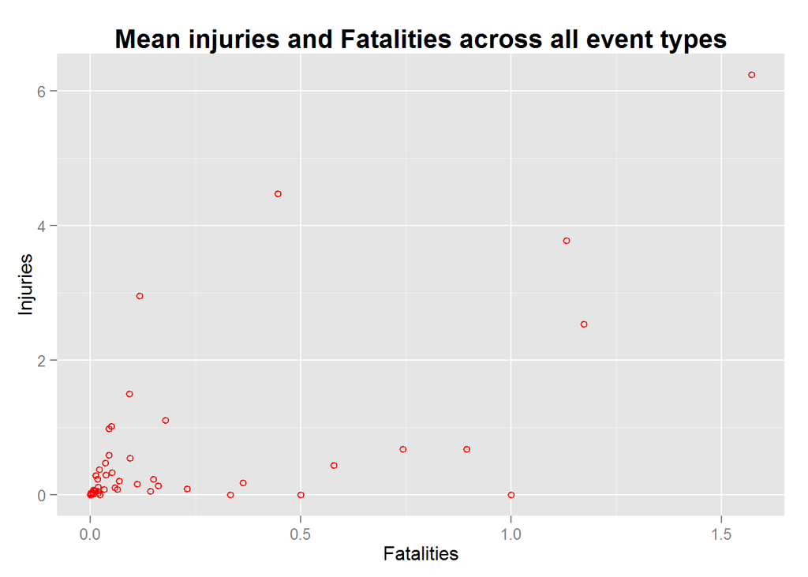

```r
pop_health_mean <- select(subset, EVTYPE, FATALITIES, INJURIES)
pop_health_mean <- group_by(pop_health_mean, EVTYPE) %>% summarize(fatalities = mean(FATALITIES), injuries = mean(INJURIES))

inj_fat_plot_mean <- ggplot(data = pop_health_mean, aes(x = fatalities, y = injuries))
inj_fat_plot_mean <- inj_fat_plot_mean + geom_point(shape = 1, size = 2, col = "red")
inj_fat_plot_mean <- inj_fat_plot_mean + scale_x_continuous(name = "Fatalities")
inj_fat_plot_mean <- inj_fat_plot_mean + scale_y_continuous(name = "Injuries")
inj_fat_plot_mean <- inj_fat_plot_mean + ggtitle("Mean injuries and Fatalities across all event types")
inj_fat_plot_mean <- inj_fat_plot_mean + theme(plot.title = element_text(lineheight=1.5, face="bold", size = 16))
inj_fat_plot_mean
```

As we can see from the plot, most events produce on average less than 2 injuries and less than 1 fatality. The worst events, i.e. those that produce on average more than 2 injuries and/or 1 fatality, are the following:

```r
res_pop_health_moredamage <- filter(pop_health_mean, injuries >= 2 | fatalities >= 1)
res_pop_health_moredamage
```

```
## Source: local data frame [7 x 3]
##
##              EVTYPE fatalities injuries
## 1          AVALANCE       1.00      0.0
## 2               ICE       0.12      3.0
## 3          DROWNING       1.00      0.0
## 4    EXCESSIVE HEAT       1.13      3.8
## 5              HEAT       1.17      2.5
## 6 HURRICANE/TYPHOON       0.45      4.5
## 7           TSUNAMI       1.57      6.2
```

The absolute worst events, i.e. those that produce on average more than 2 injuries and 1 fatality, are the following:

```r
res_pop_health_mostdamage <- filter(pop_health_mean, injuries >= 2 & fatalities >= 1)
res_pop_health_mostdamage
```

```
## Source: local data frame [3 x 3]
##
##           EVTYPE fatalities injuries
## 1 EXCESSIVE HEAT        1.1      3.8
## 2           HEAT        1.2      2.5
## 3        TSUNAMI        1.6      6.2
```

In general, the 10 event types that produced the most mean fatalities per single event are the following:

```r
pop_health <- select(subset, EVTYPE, FATALITIES, INJURIES)
pop_health <- group_by(pop_health, EVTYPE) %>% summarize(fatalities = mean(FATALITIES), injuries = mean(INJURIES))
res_pop_health_morefatal <- head(arrange(pop_health, desc(fatalities)), 10)
res_pop_health_morefatal
```

```
## Source: local data frame [10 x 3]
##
##               EVTYPE fatalities injuries
## 1            TSUNAMI       1.57     6.24
## 2               HEAT       1.17     2.54
## 3     EXCESSIVE HEAT       1.13     3.77
## 4           AVALANCE       1.00     0.00
## 5           DROWNING       1.00     0.00
## 6         HEAVY SEAS       0.89     0.68
## 7        RIP CURRENT       0.74     0.68
## 8          AVALANCHE       0.58     0.44
## 9         HIGH WATER       0.50     0.00
## 10 HURRICANE/TYPHOON       0.45     4.47
```

The 10 event types that produced the most mean injuries per single event are the following:

```r
res_pop_health_moreinjuries <- head(arrange(pop_health, desc(injuries)), 10)
res_pop_health_moreinjuries
```

```
## Source: local data frame [10 x 3]
##
##               EVTYPE fatalities injuries
## 1            TSUNAMI      1.571     6.24
## 2  HURRICANE/TYPHOON      0.446     4.47
## 3     EXCESSIVE HEAT      1.131     3.77
## 4                ICE      0.117     2.95
## 5               HEAT      1.173     2.54
## 6            TORNADO      0.093     1.51
## 7          ICY ROADS      0.179     1.11
## 8         DUST STORM      0.051     1.02
## 9          ICE STORM      0.044     0.98
## 10        HEAVY SEAS      0.895     0.68
```

The 10 most numerous events are the following (with averaged outcome):

```r
pop_health_count <- select(subset, EVTYPE, FATALITIES, INJURIES)
pop_health_count <- cbind(pop_health_count, count = rep(1, nrow(pop_health_count)))
pop_health_count <- group_by(pop_health_count, EVTYPE) %>% summarize(number_of_events = sum(count), fatalities = mean(FATALITIES), injuries = mean(INJURIES))
head(arrange(pop_health_count, desc(number_of_events)), 10)
```

```
## Source: local data frame [10 x 4]
##
##                      EVTYPE number_of_events fatalities injuries
## 1         THUNDERSTORM WIND           324976   0.002200   0.0294
## 2                      HAIL           289245   0.000052   0.0047
## 3                   TORNADO            60691   0.093226   1.5054
## 4               FLASH FLOOD            55667   0.018593   0.0324
## 5                     FLOOD            29505   0.017387   0.2330
## 6                 HIGH WIND            21902   0.013515   0.0688
## 7                HEAVY SNOW            16741   0.009856   0.0670
## 8                 LIGHTNING            15764   0.051827   0.3318
## 9                HEAVY RAIN            12074   0.008862   0.0251
## 10 MARINE THUNDERSTORM WIND            11987   0.001585   0.0028
```

Finally, the 10 most numerous events that produced on averate at least 1 casualty or 1 fatality are the following:

```r
top_10_worst_pop <- filter(pop_health_count, injuries >= 1 | fatalities >= 1) %>% arrange(desc(number_of_events))
res_pop_health_worstpop <- head(top_10_worst_pop, 10)
res_pop_health_worstpop
```

```
## Source: local data frame [10 x 4]
##
##               EVTYPE number_of_events fatalities injuries
## 1            TORNADO            60691      0.093      1.5
## 2     EXCESSIVE HEAT             1784      1.131      3.8
## 3               HEAT              984      1.173      2.5
## 4         DUST STORM              432      0.051      1.0
## 5  HURRICANE/TYPHOON              298      0.446      4.5
## 6                ICE              128      0.117      3.0
## 7          ICY ROADS               28      0.179      1.1
## 8            TSUNAMI               21      1.571      6.2
## 9           AVALANCE                1      1.000      0.0
## 10          DROWNING                1      1.000      0.0
```

### Analysis: Effects on the economy

I can find the event types that produced the most cumulated economic damages by aggregating per event type the sum of the damage to property and crops:

```r
eco_dmg <- select(subset, EVTYPE, PROPDMG, CROPDMG)
eco_dmg_total <- group_by(eco_dmg, EVTYPE) %>% summarize(total_economic_loss = sum(PROPDMG) + sum(CROPDMG))
res_eco_dmg_topdmg <- head(arrange(eco_dmg_total, desc(total_economic_loss)), 10)
res_eco_dmg_topdmg
```

```
## Source: local data frame [10 x 2]
##
##               EVTYPE total_economic_loss
## 1  HURRICANE/TYPHOON       1625988052523
## 2              FLOOD        244733486282
## 3            TORNADO         89311921892
## 4        FLASH FLOOD         57446276620
## 5        STORM SURGE         47970574000
## 6               HAIL         31289504828
## 7  THUNDERSTORM WIND         28053488626
## 8          HIGH WIND         25308419907
## 9           WILDFIRE         16266652583
## 10    TROPICAL STORM          9673460511
```

The event types that produced the most cumulated damage to property are the following:

```r
eco_dmg_prop <- group_by(eco_dmg, EVTYPE) %>% summarize(total_economic_loss = sum(PROPDMG))
res_eco_dmg_topprop <- head(arrange(eco_dmg_prop, desc(total_economic_loss)), 10)
res_eco_dmg_topprop
```

```
## Source: local data frame [10 x 2]
##
##               EVTYPE total_economic_loss
## 1              FLOOD        150223706335
## 2  HURRICANE/TYPHOON         85256410010
## 3            TORNADO         58542034579
## 4        STORM SURGE         47964724000
## 5        FLASH FLOOD         16907928187
## 6               HAIL         15974569543
## 7  THUNDERSTORM WIND         10977810856
## 8           WILDFIRE          8496628500
## 9     TROPICAL STORM          7714390550
## 10      WINTER STORM          6749497251
```

```r
eco_dmg_crop <- group_by(eco_dmg, EVTYPE) %>% summarize(total_economic_loss = sum(CROPDMG))
res_eco_dmg_topcrop <- head(arrange(eco_dmg_crop, desc(total_economic_loss)), 10)
res_eco_dmg_topcrop
```

```
## Source: local data frame [10 x 2]
##
##               EVTYPE total_economic_loss
## 1  HURRICANE/TYPHOON       1540731642513
## 2              FLOOD         94509779947
## 3        FLASH FLOOD         40538348434
## 4            TORNADO         30769887313
## 5          HIGH WIND         19208766854
## 6  THUNDERSTORM WIND         17075677769
## 7               HAIL         15314935285
## 8           WILDFIRE          7770024083
## 9            DROUGHT          3443568952
## 10    TROPICAL STORM          1959069961
```

If we consider the mean damages per single event, these are the ones that produced the worst damages on property:

```r
eco_dmg_mean <- group_by(eco_dmg, EVTYPE) %>% summarize(property_dmg = mean(PROPDMG), crop_dmg = mean(CROPDMG))

res_eco_moreprop <- head(arrange(eco_dmg_mean, desc(property_dmg)), 10)
res_eco_moreprop
```

```
## Source: local data frame [10 x 3]
##
##               EVTYPE property_dmg   crop_dmg
## 1  HURRICANE/TYPHOON    286095336 5170240411
## 2        STORM SURGE    117273164      14303
## 3     TROPICAL STORM     11067992    2810717
## 4            TSUNAMI      6860095     952381
## 5              FLOOD      5091466    3203178
## 6           WILDFIRE      2005814    1834283
## 7          ICE STORM      1947694     256869
## 8            TORNADO       964592     506993
## 9       WINTER STORM       590094      60636
## 10         LANDSLIDE       532370      32761
```

These, on the other hand, are the ones that produced the worst damages on crops:

```r
res_eco_morecrop <- head(arrange(eco_dmg_mean, desc(crop_dmg)), 10)
res_eco_morecrop
```

```
## Source: local data frame [10 x 3]
##
##               EVTYPE property_dmg   crop_dmg
## 1  HURRICANE/TYPHOON    286095336 5170240411
## 2              FLOOD      5091466    3203178
## 3     TROPICAL STORM     11067992    2810717
## 4           WILDFIRE      2005814    1834283
## 5            DROUGHT       418188    1376327
## 6            TSUNAMI      6860095     952381
## 7          HIGH WIND       278498     877033
## 8        FLASH FLOOD       303733     728229
## 9            TORNADO       964592     506993
## 10         ICE STORM      1947694     256869
```

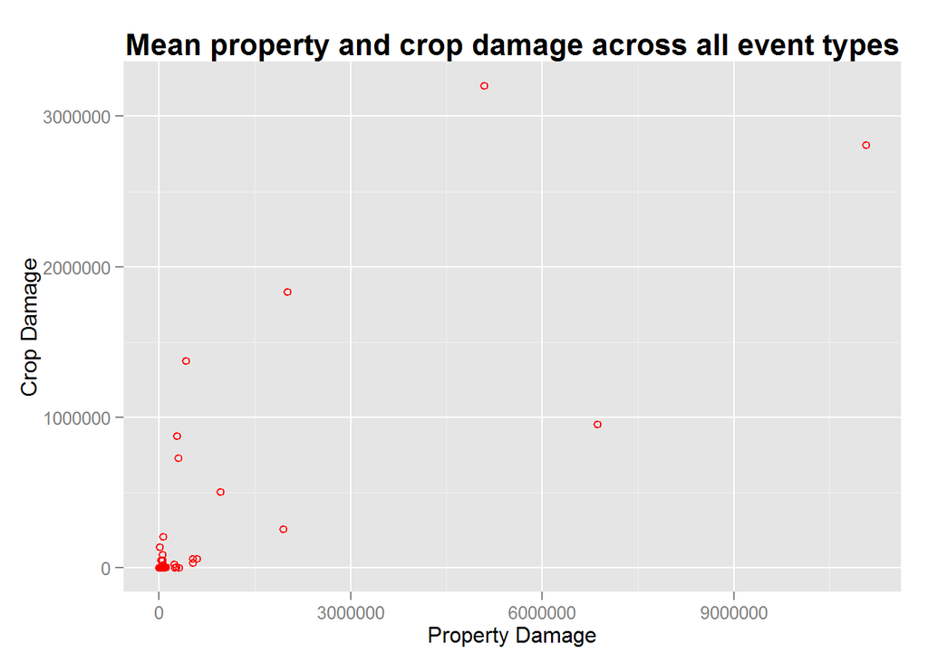

```r
prop_crop_plot_mean <- ggplot(data = eco_dmg_mean[which(eco_dmg_mean$property_dmg < 100000000),], aes(x = property_dmg, y = crop_dmg))
prop_crop_plot_mean <- prop_crop_plot_mean + geom_point(shape = 1, size = 2, col = "red")
prop_crop_plot_mean <- prop_crop_plot_mean + scale_x_continuous(name = "Property Damage")
prop_crop_plot_mean <- prop_crop_plot_mean + scale_y_continuous(name = "Crop Damage")
prop_crop_plot_mean <- prop_crop_plot_mean + ggtitle("Mean property and crop damage across all event types")
prop_crop_plot_mean <- prop_crop_plot_mean + theme(plot.title = element_text(lineheight=1.5, face="bold", size = 16))
prop_crop_plot_mean
```

The worst events, i.e. those producing on average at least than 1 million dollars of damage to either crops or property per single event, are the following:

```r
res_eco_moredamage <- filter(eco_dmg_mean, property_dmg >= 1000000 | crop_dmg >= 1000000)
res_eco_moredamage
```

```
## Source: local data frame [8 x 3]
##
##              EVTYPE property_dmg   crop_dmg
## 1             FLOOD      5091466    3203178
## 2          WILDFIRE      2005814    1834283
## 3           DROUGHT       418188    1376327
## 4         ICE STORM      1947694     256869
## 5 HURRICANE/TYPHOON    286095336 5170240411
## 6           TSUNAMI      6860095     952381
## 7       STORM SURGE    117273164      14303
## 8    TROPICAL STORM     11067992    2810717
```

The absolute worst, those producing on average at least than 1 million dollars of damage to both crops and property per single event, are the following:

```r
res_eco_mostdamage <- filter(eco_dmg_mean, property_dmg >= 1000000 & crop_dmg >= 1000000)
res_eco_mostdamage
```

```
## Source: local data frame [4 x 3]
##
##              EVTYPE property_dmg   crop_dmg
## 1             FLOOD      5091466    3203178
## 2          WILDFIRE      2005814    1834283
## 3 HURRICANE/TYPHOON    286095336 5170240411
## 4    TROPICAL STORM     11067992    2810717
```

The 10 most numerous events are the following (with averaged outcome):

```r
prop_crop_count <- select(subset, EVTYPE, PROPDMG, CROPDMG)
prop_crop_count <- cbind(prop_crop_count, count = rep(1, nrow(prop_crop_count)))
prop_crop_count <- group_by(prop_crop_count, EVTYPE) %>% summarize(number_of_events = sum(count), property_dmg = mean(PROPDMG), crop_dmg = mean(CROPDMG))
head(arrange(prop_crop_count, desc(number_of_events)), 10)
```

```
## Source: local data frame [10 x 4]
##
##                      EVTYPE number_of_events property_dmg  crop_dmg
## 1         THUNDERSTORM WIND           324976        33780   52544.4
## 2                      HAIL           289245        55229   52948.0
## 3                   TORNADO            60691       964592  506992.6
## 4               FLASH FLOOD            55667       303733  728229.4
## 5                     FLOOD            29505      5091466 3203178.4
## 6                 HIGH WIND            21902       278498  877032.5
## 7                HEAVY SNOW            16741        58403   87988.2
## 8                 LIGHTNING            15764        59549   19171.3
## 9                HEAVY RAIN            12074       267889    3905.9
## 10 MARINE THUNDERSTORM WIND            11987          489       4.2
```

```r
res_eco_worsteco <- filter(prop_crop_count, property_dmg >= 1000000 | crop_dmg >= 1000000) %>% arrange(desc(number_of_events))
res_eco_worsteco <- head(res_eco_worsteco, 10)
res_eco_worsteco
```

```
## Source: local data frame [8 x 4]
##
##              EVTYPE number_of_events property_dmg   crop_dmg
## 1             FLOOD            29505      5091466    3203178
## 2          WILDFIRE             4236      2005814    1834283
## 3           DROUGHT             2502       418188    1376327
## 4         ICE STORM             2026      1947694     256869
## 5    TROPICAL STORM              697     11067992    2810717
## 6       STORM SURGE              409    117273164      14303
## 7 HURRICANE/TYPHOON              298    286095336 5170240411
## 8           TSUNAMI               21      6860095     952381
```

## Results

Risk is usually defined as the product of the probability and severity of an event. Paraphrasing this definition, to define the most harmful types of events it is necessary to consider:

- how frequent they are;
- how severe they are.

In this analysis, we define **severity** as *the magnitude of the mean effects per single even*. We also define **frequency** as *the number of times that an event was recorded*.

An event that is very frequent, but of little consequence, does not constitute a real risk. On the other hand, a severe event that almost never happens is less of a risk than a less severe events that happened many times.

### Across the United States, which types of events are most harmful with respect to population health?

With respect to population health, the most severe events, i.e. those that produce on average more than 2 injuries and/or 1 fatality per single event, are the following:

```r
res_pop_health_moredamage
```

```
## Source: local data frame [7 x 3]
##
##              EVTYPE fatalities injuries
## 1          AVALANCE       1.00      0.0
## 2               ICE       0.12      3.0
## 3          DROWNING       1.00      0.0
## 4    EXCESSIVE HEAT       1.13      3.8
## 5              HEAT       1.17      2.5
## 6 HURRICANE/TYPHOON       0.45      4.5
## 7           TSUNAMI       1.57      6.2
```

The absolute worst events, i.e. those that produce on average more than 2 injuries and 1 fatality, are the following:

```r
res_pop_health_mostdamage
```

```
## Source: local data frame [3 x 3]
##
##           EVTYPE fatalities injuries
## 1 EXCESSIVE HEAT        1.1      3.8
## 2           HEAT        1.2      2.5
## 3        TSUNAMI        1.6      6.2
```

The 10 event types that produced the most mean fatalities per single event are the following:

```r
res_pop_health_morefatal
```

```
## Source: local data frame [10 x 3]
##
##               EVTYPE fatalities injuries
## 1            TSUNAMI       1.57     6.24
## 2               HEAT       1.17     2.54
## 3     EXCESSIVE HEAT       1.13     3.77
## 4           AVALANCE       1.00     0.00
## 5           DROWNING       1.00     0.00
## 6         HEAVY SEAS       0.89     0.68
## 7        RIP CURRENT       0.74     0.68
## 8          AVALANCHE       0.58     0.44
## 9         HIGH WATER       0.50     0.00
## 10 HURRICANE/TYPHOON       0.45     4.47
```

The 10 event types that produced the most mean injuries per single event are the following:

```r
res_pop_health_moreinjuries
```

```
## Source: local data frame [10 x 3]
##
##               EVTYPE fatalities injuries
## 1            TSUNAMI      1.571     6.24
## 2  HURRICANE/TYPHOON      0.446     4.47
## 3     EXCESSIVE HEAT      1.131     3.77
## 4                ICE      0.117     2.95
## 5               HEAT      1.173     2.54
## 6            TORNADO      0.093     1.51
## 7          ICY ROADS      0.179     1.11
## 8         DUST STORM      0.051     1.02
## 9          ICE STORM      0.044     0.98
## 10        HEAVY SEAS      0.895     0.68
```

Finally, the most numerous events that produced on averate at least 1 casualty or 1 fatality are the following:

```r
res_pop_health_worstpop
```

```
## Source: local data frame [10 x 4]
##
##               EVTYPE number_of_events fatalities injuries
## 1            TORNADO            60691      0.093      1.5
## 2     EXCESSIVE HEAT             1784      1.131      3.8
## 3               HEAT              984      1.173      2.5
## 4         DUST STORM              432      0.051      1.0
## 5  HURRICANE/TYPHOON              298      0.446      4.5
## 6                ICE              128      0.117      3.0
## 7          ICY ROADS               28      0.179      1.1
## 8            TSUNAMI               21      1.571      6.2
## 9           AVALANCE                1      1.000      0.0
## 10          DROWNING                1      1.000      0.0
```

### Across the United States, which types of events have the greatest economic consequences?

With respect to the economy, the most severe events, i.e. those that produce on average more than 1 million dollars of property and/or crop damage per single event, are the following:

```r
res_eco_moredamage
```

```
## Source: local data frame [8 x 3]
##
##              EVTYPE property_dmg   crop_dmg
## 1             FLOOD      5091466    3203178
## 2          WILDFIRE      2005814    1834283
## 3           DROUGHT       418188    1376327
## 4         ICE STORM      1947694     256869
## 5 HURRICANE/TYPHOON    286095336 5170240411
## 6           TSUNAMI      6860095     952381
## 7       STORM SURGE    117273164      14303
## 8    TROPICAL STORM     11067992    2810717
```

The absolute worst events, i.e. those that produce on average more than 1 million dollars of property and crop damage, are the following:

```r
res_eco_mostdamage
```

```
## Source: local data frame [4 x 3]
##
##              EVTYPE property_dmg   crop_dmg
## 1             FLOOD      5091466    3203178
## 2          WILDFIRE      2005814    1834283
## 3 HURRICANE/TYPHOON    286095336 5170240411
## 4    TROPICAL STORM     11067992    2810717
```

The 10 event types that produced the most mean property damages per single event are the following:

```r
res_eco_moreprop
```

```
## Source: local data frame [10 x 3]
##
##               EVTYPE property_dmg   crop_dmg
## 1  HURRICANE/TYPHOON    286095336 5170240411
## 2        STORM SURGE    117273164      14303
## 3     TROPICAL STORM     11067992    2810717
## 4            TSUNAMI      6860095     952381
## 5              FLOOD      5091466    3203178
## 6           WILDFIRE      2005814    1834283
## 7          ICE STORM      1947694     256869
## 8            TORNADO       964592     506993
## 9       WINTER STORM       590094      60636
## 10         LANDSLIDE       532370      32761
```

The 10 event types that produced the most mean crop damages per single event are the following:

```r
res_eco_morecrop
```

```
## Source: local data frame [10 x 3]
##
##               EVTYPE property_dmg   crop_dmg
## 1  HURRICANE/TYPHOON    286095336 5170240411
## 2              FLOOD      5091466    3203178
## 3     TROPICAL STORM     11067992    2810717
## 4           WILDFIRE      2005814    1834283
## 5            DROUGHT       418188    1376327
## 6            TSUNAMI      6860095     952381
## 7          HIGH WIND       278498     877033
## 8        FLASH FLOOD       303733     728229
## 9            TORNADO       964592     506993
## 10         ICE STORM      1947694     256869
```

```r
res_eco_worsteco
```

```
## Source: local data frame [8 x 4]
##
##              EVTYPE number_of_events property_dmg   crop_dmg
## 1             FLOOD            29505      5091466    3203178
## 2          WILDFIRE             4236      2005814    1834283
## 3           DROUGHT             2502       418188    1376327
## 4         ICE STORM             2026      1947694     256869
## 5    TROPICAL STORM              697     11067992    2810717
## 6       STORM SURGE              409    117273164      14303
## 7 HURRICANE/TYPHOON              298    286095336 5170240411
## 8           TSUNAMI               21      6860095     952381
```